# habitat-covariates

Liz Stebbins

2024-11-25

# Pull in habitat data for Tuolumne

These data were initially pulled to feed into analysis for VA habitat modeling, but are necessary for fitting a stock-recruit (SR) model. Here, habitat data are described, analyzed for suitability in the SR model, and summarized in different formats. Limitations for use in the SR model, like overlap with RST data and adult data, will be done once those data are ready.

Flow-habitat curves were provided for the Tuolumne by the Tuolumne parties in June 2024. These data contained relationships for spawning, rearing (floodplain and instream), and wetted area. Updated data were provided for rearing and wetted acres that split out floodplain and instream into separate curves. Therefore the habitat was functionalized as following:

- Spawning: Curve functionalized.
- Instream rearing: Curve functionalized from updated Oct 2024 data.
- Floodplain rearing: Curve functionalized from updated Oct 2024 data.
- Wetted area: provided by the Tuolumne parties as separate for instream and floodplain. These were functionalized separately and instream wetted area was used for `spawning` and `rearing` covariates, and floodplain wetted area used for `floodplain` covariates. Instream and floodplain wetted area were summed to create combined wetted area for combined rearing covariates. Does not represent suitable habitat.

Historical flows and temperatures were pulled in from USGS gage `11290000`.

# Create habitat using historical flows

# Covariate processing

The proposed covariate structures for habitat are:

- Spawning habitat (Oct. 1 – December 31):
  - Mean wetted acres
  - Mean WUA
  - Mean WUA with temperature filter applied
- In-channel rearing habitat (Jan 1 – June 31):
  - Mean wetted acres
  - Mean WUA
  - Mean WUA with temperature filter applied
- Floodplain rearing habitat (Jan 1 – June 31):
  - Mean acres inundated per day based on wetted area
  - Total acre-days for the season of floodplain inundation based on wetted area
  - Mean acres inundated per day based on WUA
  - Total acre-days for the season of floodplain inundation based on WUA
  - Mean acres inundated per day based on WUA with temperature filter applied
  - Total acre-days for the season of floodplain inundation based on WUA with temperature filter applied
- Total rearing habitat (Jan 1 – June 31):
  - Mean wetted acres
  - Mean WUA
  - Mean WUA with temperature filter applied

## Spawning habitat covariates

Time frame is October - December.

- Mean wetted acres (instream)
- Mean WUA
- Mean WUA with temperature filter applied

## In-channel rearing habitat covariates

Time frame is January - June.

- Mean wetted acres (instream)
- Mean WUA
- Mean WUA with temperature filter applied

## Floodplain rearing habitat

Timeframe is January - June.

- Mean acres inundated per day based on wetted area (floodplain)
- Total acre-days for the season of floodplain inundation based on wetted area
- Mean acres inundated per day based on WUA
- Total acre-days for the season of floodplain inundation based on WUA
- Mean acres inundated per day based on WUA with temperature filter applied
- Total acre-days for the season of floodplain inundation based on WUA with temperature filter applied

## Total rearing habitat covariates

Time frame is January - June.

- Mean wetted acres (combined)
- Mean WUA
- Mean WUA with temperature filter applied

# All covariates

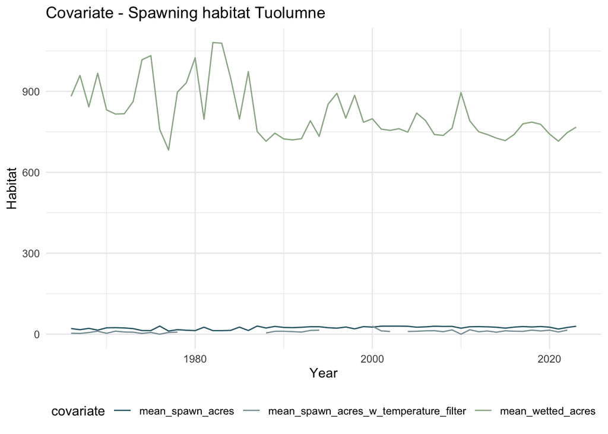

```r
mean_annual_spawning_habitat |>
  ggplot(aes(x = year, y = value, color = covariate)) +
  geom_line() +
  theme_minimal() +
  theme(legend.position = "bottom") +
  scale_color_manual(values = colors) +
  labs(title = "Covariate - Spawning habitat Tuolumne",
     x = "Year",
     y = "Habitat")
```

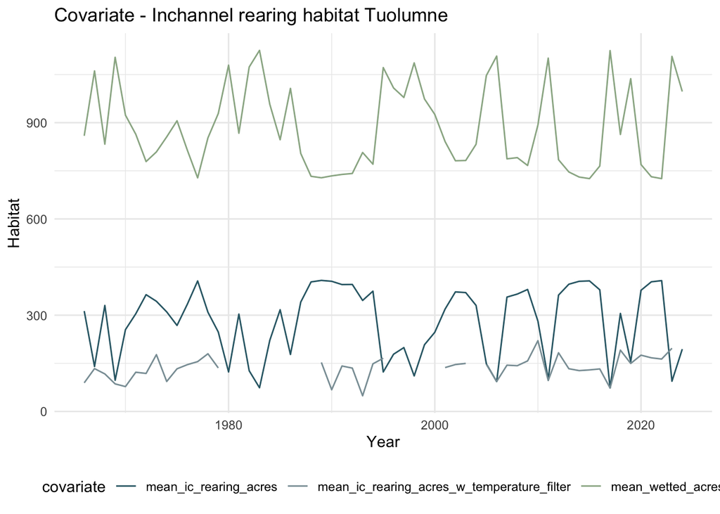

```r
mean_annual_ic_rearing_habitat |>
  ggplot(aes(x = year, y = value, color = covariate)) +
  geom_line() +
  theme_minimal() +
  theme(legend.position = "bottom") +
  scale_color_manual(values = colors) +
  labs(title = "Covariate - Inchannel rearing habitat Tuolumne",
     x = "Year",
     y = "Habitat")
```

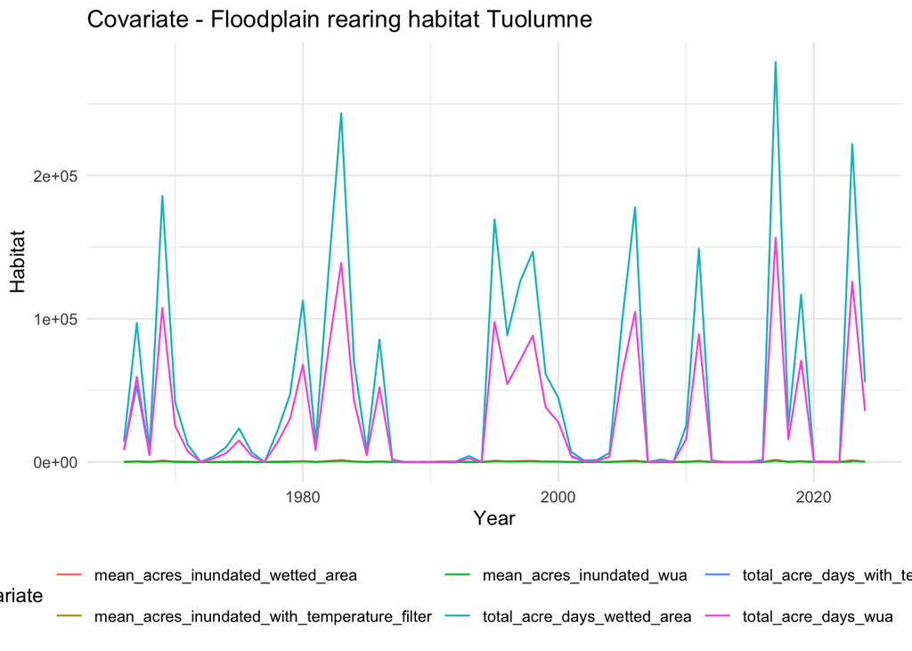

```r
mean_annual_fp_rearing_habitat |>
  ggplot(aes(x = year, y = value, color = covariate)) +
  geom_line() +
  theme_minimal() +
  theme(legend.position = "bottom") +
  labs(title = "Covariate - Floodplain rearing habitat Tuolumne",
     x = "Year",
     y = "Habitat")
```

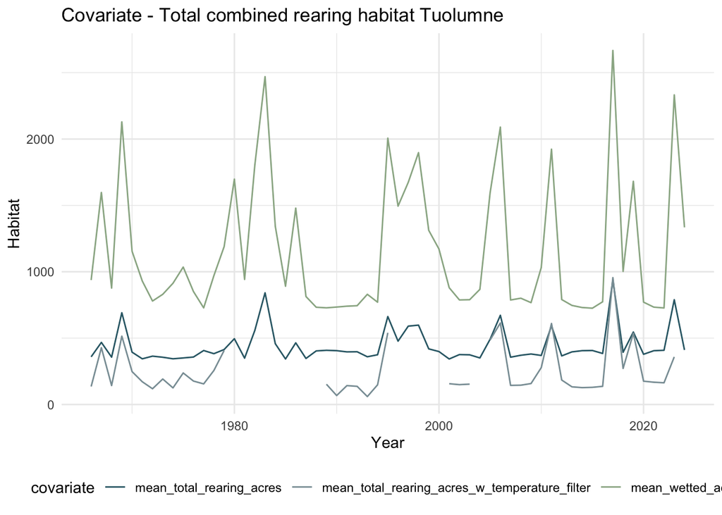

```r
mean_annual_total_rearing_habitat |>
  ggplot(aes(x = year, y = value, color = covariate)) +
  geom_line() +
  theme_minimal() +
  theme(legend.position = "bottom") +
  scale_color_manual(values = colors) +
  labs(title = "Covariate - Total combined rearing habitat Tuolumne",
     x = "Year",
     y = "Habitat")
```

*Final habitat covariates do not include any with a temperature filter*